# Explore effect of reduced stomach sampling

Author

Max Lindmark

Published

October 11, 2025

## Load libraries

```r
library(tidyverse)
library(devtools)
library(sdmTMB)
library(sdmTMBextra)
library(tidylog)
library(viridis)
library(egg)
library(tictoc)
library(mapplots)
library(purrr)
library(patchwork)

# Set path
home <- here::here()

devtools::source_url("https://raw.githubusercontent.com/maxlindmark/pred-prey-overlap/main/R/functions/map-plot.R")
set.seed(99)
```

```r
# To load entire cache in interactive r session, do:
# qwraps2::lazyload_cache_dir(path = paste0(home, "/R/main-analysis/02-fit-diet-models_cache/html"))
```

## Read cleaned data

```r
d <- read_csv(paste0(home, "/data/clean/stomachs.csv")) |>
  pivot_wider(names_from = "prey_group", values_from = "rpw") |>
  mutate(Other = Other + `Other invertebrates` + `Other pisces` + Saduria) |>
  dplyr::select(-`Other invertebrates`, -`Other pisces`, -Saduria) |>
  pivot_longer(c("Other", "Sprat", "Herring"),
               names_to = "prey_group", values_to = "rpw") |>
  mutate(
    year_f = as.factor(year),
    month_f = as.factor(month)
  ) |>
  filter(quarter %in% c(1, 4)) |>
  mutate(across(
    .cols = c("oxy", "temp", "depth", "salinity", "pred_length"),
    .fns = scale,
    .names = "{.col}_sc"
  )) |>
  # Instead of filtering high rpw, I assign them the max
  mutate(rpw = ifelse(rpw > 0.5, 0.5, rpw)) |>
  mutate(
    prey_group = as.factor(prey_group),
    year_ct = year - 2000
  )

pred_grid <-
  bind_rows(
    read_csv(paste0(home, "/data/clean/pred_grid_(1_2).csv")),
    read_csv(paste0(home, "/data/clean/pred_grid_(2_2).csv"))
  ) |>
  filter(year >= 1995 & year <= 2023) |>
  filter(quarter == 4) |> # Not needed in theory for saduria...
  mutate(
    year_ct = year - 2000,
    year_f = as.factor(year),
    oxy_sc = (oxy - mean(d$oxy)) / sd(d$oxy),
    temp_sc = (temp - mean(d$temp)) / sd(d$temp),
    depth_sc = (depth - mean(d$depth)) / sd(d$depth),
    salinity_sc = (salinity - mean(d$salinity)) / sd(d$salinity),
    pred_length_sc = 0
  )
```

## Plot sample size by data source

```
summarise: now 62 rows and 4 columns, ungrouped
```

```
mutate: converted 'data_source' from character to factor (0 new NA)
```

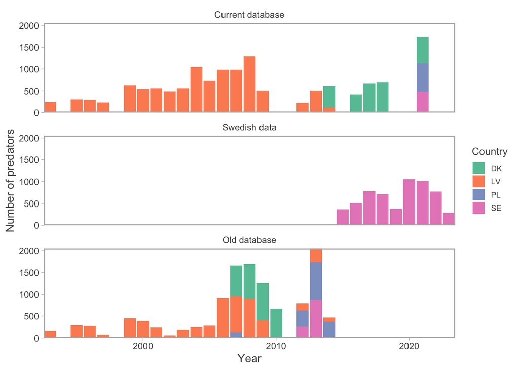

```r
d |>
  summarise(
    n = length(unique(pred_id)),
    .by = c(year, data_source, Country)
  ) |>
  mutate(data_source = forcats::fct_recode(data_source,
    "Current database" = "new_db",
    "Swedish data" = "new_SE",
    "Old database" = "old_db"
  )) |>
  ggplot(aes(year, n, fill = Country)) +
  geom_col() +
  facet_wrap(~data_source, ncol = 1) +
  coord_cartesian(expand = 0) +
  scale_fill_brewer(palette = "Set2") +
  labs(
    y = "Number of predators",
    x = "Year"
  )
```

```r
ggsave(paste0(home, "/figures/sample_by_db.png"), width = 17, height = 17, units = "cm")
```

## Plot sample size in space

```r
# Sample size in space
d_haul <- d |>
  summarise(n = length(unique(pred_id)), .by = c(X, Y, year, haul_id))
```

```
summarise: now 1,950 rows and 5 columns, ungrouped
```

```r
p1 <- plot_map +
  geom_point(
    data = d_haul, aes(X * 1000, Y * 1000, color = year, size = n),
    alpha = 0.5
  ) +
  scale_size(range = c(0.1, 4)) +
  theme(legend.position = "bottom") +
  labs(color = "Year") +
  scale_color_viridis(option = "A") +
  theme(
    legend.key.width = unit(0.9, "cm"),
    legend.box = "vertical"
  ) +
  geom_sf(color = "gray80")

d_country <- d |>
  summarise(n = length(unique(pred_id)), .by = c(X, Y, year, haul_id, Country))
```

```
summarise: now 1,950 rows and 6 columns, ungrouped
```

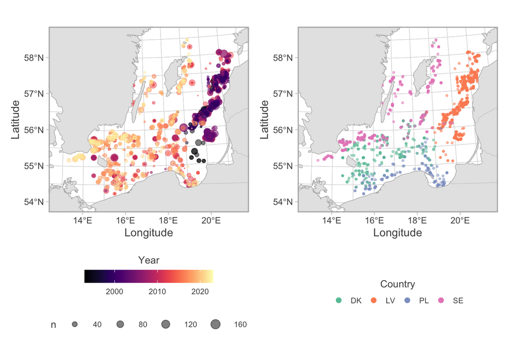

```r
p2 <- plot_map +
  geom_point(
    data = d_country, aes(X * 1000, Y * 1000, color = Country),
    alpha = 0.5, size = 0.7
  ) +
  guides(colour = guide_legend(
    title.position = "top", title.hjust = 0.5,
    override.aes = list(size = 2, alpha = 1)
  )) +
  scale_color_brewer(palette = "Set2") +
  geom_sf(color = "gray80")

(p1 + p2) & theme(legend.position = "bottom")
```

```r
ggsave(paste0(home, "/figures/sample_in_space.png"), width = 21, height = 14, units = "cm")
```

## Sub-sample data, store in list and fit models to a loop

Following Anderson et al 2024 (testing the effect of MPA for index trend estimates), we’d use all data (from a given time-period), fit a model to that and calculate an area-expanded index. Since the true mean is unknown, we’d treat this as our best estimate of the mean for each year. Next we would refit the same model (or as complex a model is allowed) to a subset of the data following a set of sampling designs:

1. Keep 1 random haul per ICES rectangle, 1 fish from each cm class
2. Keep 1 random haul per ICES rectangle and strata, 1 fish from each cm class / Mich: 2 depth strata enough
3. All hauls, 2 fish from each 5 cm class
4. Same as now (all hauls, 1 per cm class + ensure range of depths are kept), but sample every other year
5. 10 stomachs per 5 cm length class per subdivision
6. 2 stomachs per 5 cm per rectangle

```r
# I don't only want to sample, I want to repeat this processes many times

iter <- c(1:30)

dlist <- list()

for(i in iter){

  s1 <- d |>
    group_by(year, quarter, ices_rect) |>
    filter(haul_id %in% sample(unique(haul_id), 1)) |>
    group_by(year, quarter, haul_id, ices_rect, pred_length) |>
    filter(pred_id %in% sample(unique(pred_id), 1)) |>
    ungroup()

  s2 <- d |>
    #mutate(depth_strata = ifelse(depth < 40, "shallow", "deep")) |>
    mutate(depth2 = ifelse(depth >= 100, 100, depth)) |>
    mutate(depth_strata = cut(depth2,
                              breaks = c(0, 20, 40, 60, 80, 100),
                              labels = c("0-20", "21-40", "41-60", "61-80", "81-100"),
                              include.lowest = TRUE)) |>
    group_by(year, quarter, ices_rect, depth_strata) |>
    filter(haul_id %in% sample(unique(haul_id), 1)) |>
    group_by(year, quarter, haul_id, ices_rect, pred_length) |>
    filter(pred_id %in% sample(unique(pred_id), 1)) |>
    ungroup()

  s3 <- d |>
    mutate(length_group = cut(pred_length, breaks = seq(0, 115, by = 5))) |>
    group_by(year, quarter, haul_id, length_group) |>
    filter(pred_id %in% sample(
      unique(pred_id),
      size = min(2, length(unique(pred_id))),
      replace = FALSE
      )) |>
    ungroup()

  s4 <- d |>
    filter(year %in% seq(min(d$year), max(d$year), by = 2))

  s5 <- d |>
    mutate(length_group = cut(pred_length, breaks = seq(0, 115, by = 5))) |>
    # Sample max 2 per haul_id (per 5 cm bin)
    group_by(year, quarter, haul_id, length_group) |>
    mutate(n_pred = n_distinct(pred_id)) |>
    filter(pred_id %in% sample(unique(pred_id),
                               size = min(2, n_pred),
                               replace = FALSE)) |>
    ungroup() |>
    # Sample up to 10 per length_group per sub_division & country
    group_by(year, quarter, sub_div, length_group, Country) |>
    mutate(n_pred = n_distinct(pred_id)) |>
    filter(pred_id %in% sample(unique(pred_id),
                               size = min(10, n_pred),  # up to 10 per bin per sub_div
                               replace = FALSE)) |>
    ungroup()

  s6 <- d |>
  mutate(length_group = cut(pred_length, breaks = seq(0, 115, by = 5))) |>
  # Sample max 2 per haul_id (per 5 cm bin)
  group_by(year, quarter, haul_id, length_group) |>
  mutate(n_pred = n_distinct(pred_id)) |>
  filter(pred_id %in% sample(
    unique(pred_id),
    size = min(2, n_pred),
    replace = FALSE
  )) |>
  ungroup() |>
  # Sample up to 2 per rectangle (per 5 cm bin)
  group_by(year, quarter, ices_rect, length_group, Country) |>
  mutate(n_pred = n_distinct(pred_id)) |>
  filter(pred_id %in% sample(
    unique(pred_id),
    size = min(2, n_pred),
    replace = FALSE
  )) |>
  ungroup()

  d_all <- bind_rows(
    d  |> mutate(scenario = "all", iter = i),
    s1 |> mutate(scenario = "s1",  iter = i),
    s2 |> mutate(scenario = "s2",  iter = i),
    s3 |> mutate(scenario = "s3",  iter = i),
    s4 |> mutate(scenario = "s4",  iter = i),
    s5 |> mutate(scenario = "s5",  iter = i),
    s6 |> mutate(scenario = "s6",  iter = i)
    )

    dlist[[i]] <- d_all

}

df <- bind_rows(dlist)

d |>
  summarise(n = length(unique(haul_id)),
            .by = c(year, quarter, subdiv)) |>
  summarise(mean = mean(n))
```

```
# A tibble: 1 × 1
   mean
  <dbl>
1  14.3
```

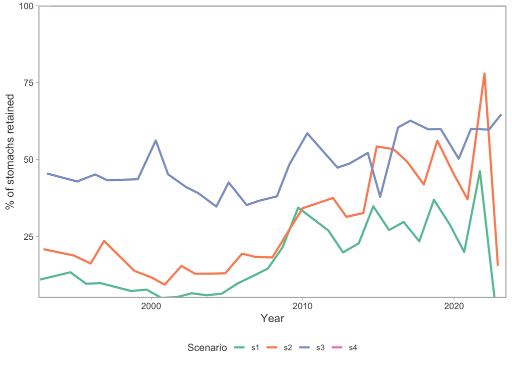

```r
n_pred_ids <- function(data, scenario_name) {
  data |>
    filter(scenario == scenario_name) |>
    summarise(n = length(unique(pred_id)), .by = c(year, iter)) |>
    mutate(Scenario = scenario_name)
}

dn  <- n_pred_ids(df, "all")
s1n <- n_pred_ids(df, "s1")
s2n <- n_pred_ids(df, "s2")
s3n <- n_pred_ids(df, "s3")
s4n <- n_pred_ids(df, "s4")
s5n <- n_pred_ids(df, "s5")
s6n <- n_pred_ids(df, "s6")

dsum <- bind_rows(s1n, s2n, s3n, s4n
                  #, s5n, s6n
                  ) |>
  # Calculate mean + se across iterations, by scenario
  summarise(mean = mean(n),
            sd = sd(n),
            .by = c(Scenario, year)) |>
  left_join(
    dn |>
      filter(iter == 1) |> # They are the same across all iters anyway...
      rename(n_ref = n) |>
      dplyr::select(-Scenario),
    by = c("year")
    ) |>
  mutate(Percent = (mean / n_ref) * 100,
         upr = ((mean + sd) / n_ref) * 100,
         lwr = ((mean - sd) / n_ref) * 100)

pd <- position_dodge(width = 0.9)

ggplot(dsum, aes(year, Percent, color = Scenario)) +
  geom_line(position = pd, linewidth = 1) +
  scale_color_brewer(palette = "Set2") +
  coord_cartesian(expand = 0) +
  labs(x = "Year", y = "% of stomachs retained") +
  theme(
    legend.position = "bottom"
  ) +
  guides(fill = guide_legend(title.position = "top", title.hjust = 0.5))
```

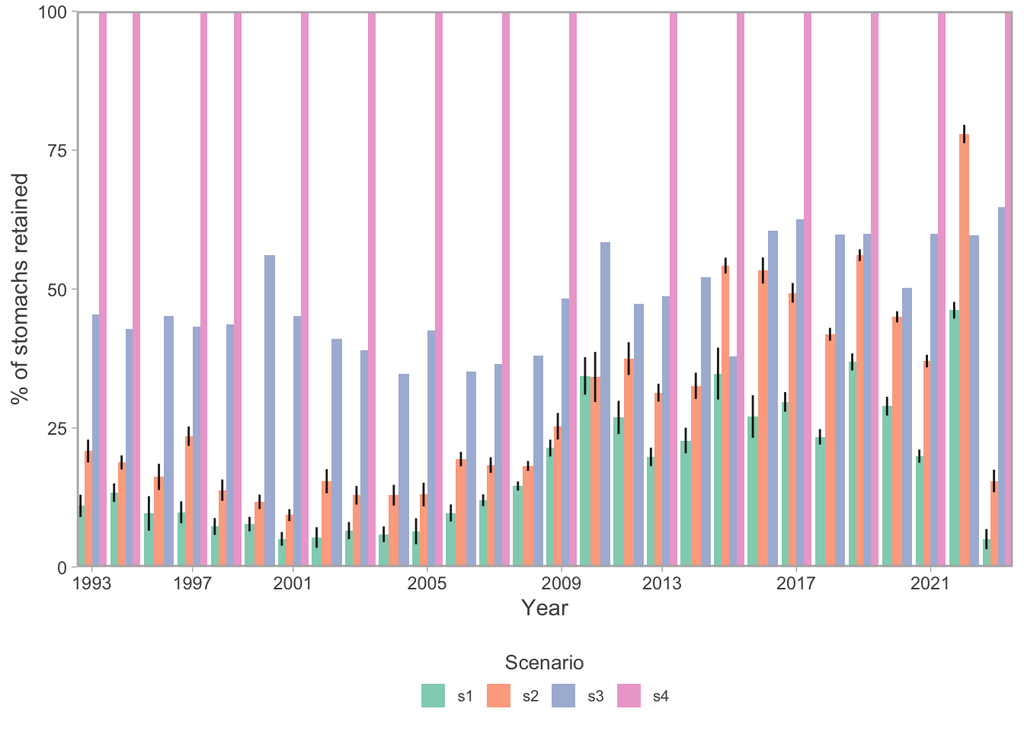

```r
ggplot(dsum, aes(as.factor(year), Percent, fill = Scenario)) +
  geom_col(position = pd, alpha = 0.75) +
  scale_x_discrete(
    breaks = seq(min(dsum$year), max(dsum$year), by = 4)
    ) +
  geom_errorbar(aes(as.factor(year), Percent, ymin = lwr, ymax = upr),
                position = pd, alpha = 0.9, width = 0, color = "black") +
  scale_fill_brewer(palette = "Set2") +
  scale_color_brewer(palette = "Set2") +
  coord_cartesian(expand = 0) +
  labs(x = "Year", y = "% of stomachs retained") +
  theme(
    legend.position = "bottom"
  ) +
  guides(fill = guide_legend(title.position = "top", title.hjust = 0.5))
```

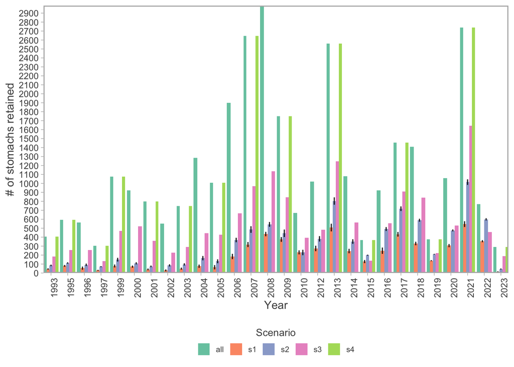

```r
ggsave(paste0(home, "/figures/sample_size.png"), width = 27, height = 17, units = "cm")

# Absolute numbers instead of relative
bind_rows(dn, s1n, s2n, s3n, s4n
          #s5n, s6n
          ) |>
  summarise(mean = mean(n),
            sd = sd(n),
            .by = c(Scenario, year)) |>
  ggplot(aes(as.factor(year), mean, fill = Scenario)) +
  geom_col(position = "dodge", alpha = 0.9) +
  geom_errorbar(aes(as.factor(year), mean, ymin = mean - sd, ymax = mean + sd),
                position = pd, alpha = 0.9, width = 0, color = "black") +
  scale_fill_brewer(palette = "Set2") +
  coord_cartesian(expand = 0) +
  labs(x = "Year", y = "# of stomachs retained") +
  theme(
    legend.position = "bottom",
    axis.text.x = element_text(angle = 90)
  ) +
  scale_y_continuous(breaks = seq(0, 5000, by = 100)) +
  guides(fill = guide_legend(title.position = "top", title.hjust = 0.5))
```

```r
ggsave(paste0(home, "/figures/abs_sample_size.png"), width = 17, height = 17, units = "cm")

# Combine all scenarios for plotting and model fitting (for a given iteration)
for (i in unique(df$scenario)) {

  sub <- df |>
    filter(scenario == i & iter == 1) |>
    summarise(n = length(unique(pred_id)),
              .by = c(ices_rect, year, month)) |>
    mutate(mid_lat = ices.rect(ices_rect)$lat,
           mid_lon = ices.rect(ices_rect)$lon) |>
    tidylog::drop_na(mid_lat) |>
    add_utm_columns(
      ll_names = c("mid_lon", "mid_lat"),
      utm_names = c("mid_X", "mid_Y"),
      utm_crs = 32633
    ) |>
    distinct(ices_rect, year, .keep_all = TRUE)

  plot_map_fc +
    geom_sf(color = "gray80") +
    geom_text(data = sub, aes(mid_X * 1000, mid_Y * 1000, label = n), size = 1.8, color = "tomato3") +
    facet_wrap(~year) +
    labs(caption = "Number of stomachs sampled")

  ggsave(paste0(home, "/figures/supp/sample_size_map_", i, ".png"), width = 20, height = 20, units = "cm")
}
```

```r
# Loop through all scenarios, fit model and calculate index

df <- df |> filter(!scenario %in% c("s5", "s6"))

inds <- list()
inds_all <- list()

df$scen_iter <- paste(df$scenario, df$iter, sep = "_")

for (i in unique(df$scen_iter)) {

  dd <- df |> filter(scen_iter == i)

  mesh <- make_mesh(dd, c("X", "Y"), cutoff = 15)

  ggplot() +
    inlabru::gg(mesh$mesh) +
    coord_fixed() +
    geom_point(aes(X, Y), data = d, alpha = 0.2, size = 0.5) +
    annotate("text", -Inf, Inf, label = paste("n knots = ", mesh$mesh$n), hjust = -0.3, vjust = 3) +
    labs(x = "Easting (km)", y = "Northing (km)")

  ggsave(paste0(home, "/figures/supp/diet_mesh_", i, ".png"), width = 14, height = 14, units = "cm")

  # Fit models
  missing_years <- base::setdiff(
    min(d$year):max(d$year),
    unique(dd$year)
  )

  tryCatch(
    {
    # Fit the model
    m <- sdmTMB(
    rpw ~ 0 + prey_group * pred_length_sc + s(year_ct, by = prey_group) + oxy_sc + temp_sc + depth_sc + salinity_sc,
    data = dd,
    mesh = mesh,
    time = "year",
    extra_time = missing_years,
    spatial = "off",
    spatiotemporal = "off",
    spatial_varying = ~ 0 + prey_group,
    family = delta_beta()
    )

    sanity(m)
    tidy(m)

    # s <- simulate(m, nsim = 300, type = "mle-mvn")
    # dharma_residuals(s, m)

    # Calculate indices
    for (j in unique(d$prey_group)) {

      pred_grid$prey_group <- as.factor(j)

      p <- predict(m, newdata = pred_grid, return_tmb_object = TRUE)

      t <- get_index(p, area = 1 / nrow(pred_grid |> filter(year == 2000)))

      inds[[j]] <- t |>
        mutate(
          prey_group = j,
          scenario = i
        )
      }

  },

  error = function(e) {
    message("⚠️ Model ", i, " failed: ", e$message)
    NULL  # store NULL if model fails
  }
)

  inds_all[[i]] <- bind_rows(inds)

}
```

```r
ind <- bind_rows(inds_all)

write_csv(ind, paste0(home, "/output/index.csv"))
```

Average across iterations!

```r
ind <- read_csv(paste0(home, "/output/index.csv")) |>
  separate(scenario, into = c("scenario", "iteration"), remove = TRUE) #|>
  #filter(iteration == 1)

# Add calculations to the index
data_avg <- df |>
  #filter(iter == 1) |>
  summarise(y_mean = mean(rpw), .by = c(year, scenario, prey_group))

ind_sum <- ind |>
  summarise(est = mean(est, na.rm = TRUE),
            lwr = mean(lwr, na.rm = TRUE),
            upr = mean(upr, na.rm = TRUE),
            log_est = mean(log_est),
            se = mean(se, na.rm = TRUE),
            .by = c(year, prey_group, scenario)) |>
  left_join(data_avg, by = c("prey_group", "scenario", "year"))

ind_sum
```

```
# A tibble: 435 × 9
    year prey_group scenario     est     lwr     upr log_est     se   y_mean
   <dbl> <chr>      <chr>      <dbl>   <dbl>   <dbl>   <dbl>  <dbl>    <dbl>
 1  1995 Other      all      0.0101  0.00914 0.0113    -4.59 0.0534  0.00637
 2  1996 Other      all      0.00995 0.00904 0.0110    -4.61 0.0488  0.00150
 3  1997 Other      all      0.0101  0.00930 0.0111    -4.59 0.0445  0.00418
 4  1998 Other      all      0.0104  0.00966 0.0113    -4.56 0.0396 NA
 5  1999 Other      all      0.0108  0.0101  0.0116    -4.53 0.0368  0.00772
 6  2000 Other      all      0.0108  0.0101  0.0116    -4.53 0.0355  0.00812
 7  2001 Other      all      0.0106  0.00991 0.0114    -4.54 0.0351  0.00934
 8  2002 Other      all      0.0100  0.00934 0.0108    -4.60 0.0360  0.0122
 9  2003 Other      all      0.00950 0.00883 0.0102    -4.66 0.0373  0.0128
10  2004 Other      all      0.00904 0.00841 0.00972   -4.71 0.0370  0.00654
# ℹ 425 more rows
```

```r
# See Anderson et al for these calculations
all_scen <- ind_sum |>
  filter(scenario == "all") |>
  dplyr::select(year, est, se, prey_group) |>
  rename(
    est_ref = est,
    se_ref = se
  )

ind_sum |>
  filter(scenario == "s2")
```

```
# A tibble: 87 × 9
    year prey_group scenario     est     lwr     upr log_est     se   y_mean
   <dbl> <chr>      <chr>      <dbl>   <dbl>   <dbl>   <dbl>  <dbl>    <dbl>
 1  1995 Other      s2       0.0101  0.00849 0.0120    -4.60 0.0881  0.00530
 2  1996 Other      s2       0.0101  0.00867 0.0118    -4.60 0.0784  0.00175
 3  1997 Other      s2       0.0101  0.00876 0.0116    -4.60 0.0718  0.00470
 4  1998 Other      s2       0.00986 0.00864 0.0113    -4.62 0.0674 NA
 5  1999 Other      s2       0.00974 0.00856 0.0111    -4.63 0.0657  0.00712
 6  2000 Other      s2       0.00947 0.00835 0.0107    -4.66 0.0641  0.00781
 7  2001 Other      s2       0.00933 0.00827 0.0105    -4.68 0.0617  0.00745
 8  2002 Other      s2       0.00899 0.00799 0.0101    -4.71 0.0600  0.0123
 9  2003 Other      s2       0.00870 0.00776 0.00975   -4.75 0.0580  0.0109
10  2004 Other      s2       0.00839 0.00754 0.00934   -4.78 0.0543  0.00523
# ℹ 77 more rows
```

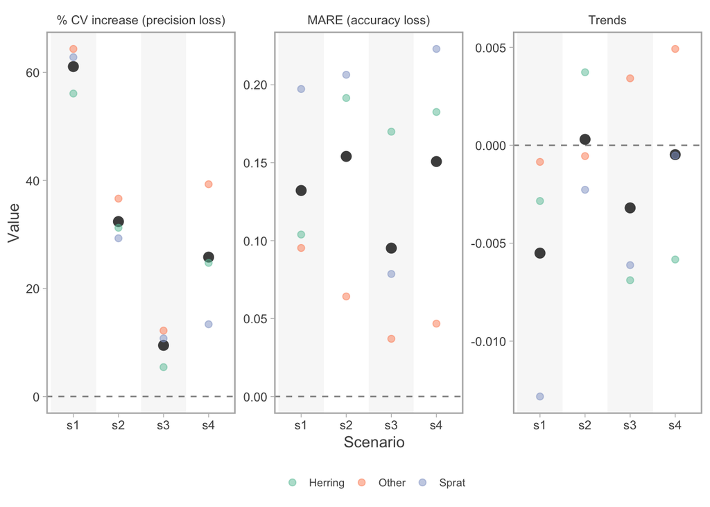

```r
ind_comp <- ind_sum |>
  filter(!scenario == "all") |>
  left_join(all_scen, by = c("year", "prey_group")) |>
  mutate(
    precision = sqrt(exp((se^2)) - 1),
    precision_ref = sqrt(exp((se_ref^2)) - 1),
    CV = ((precision - precision_ref) / precision_ref) * 100,
    RE = (est - est_ref) / est_ref,
    abs_RE = abs(RE)) |>
  pivot_longer(c(CV, RE, abs_RE))

# Now get bias in trends over time
slopes <- ind_comp |>
  filter(name == "RE") |>
  mutate(id = paste(prey_group, scenario, sep = ":")) %>%
  split(.$id) |>
  purrr::map(~ lm(value ~ year, data = .x)) |>
  purrr::map_df(broom::tidy, .id = "id") |>
  dplyr::select(id, term, estimate, std.error) |>
  filter(term == "year") |>
  dplyr::select(-term) |>
  mutate(
    lwr = estimate - 1.96 * std.error,
    upr = estimate + 1.96 * std.error
  ) |>
  separate(id, into = c("prey_group", "scenario"), sep = ":") |>
  rename(median = estimate) |>
  mutate(name = "Trends") |>
  dplyr::select(-std.error)

ind_comp_sp <- ind_comp |>
  summarise(
    median = median(value, na.rm = TRUE),
    lwr = quantile(value, probs = 0.25, na.rm = TRUE),
    upr = quantile(value, probs = 0.75, na.rm = TRUE),
    .by = c(name, prey_group, scenario)
  ) |>
  mutate(name = ifelse(name == "abs_RE", "MARE", name)) |>
  filter(!name == "RE")

metrics <- bind_rows(ind_comp_sp, slopes)

# Plot precision, accuracy (abs_RE) and trends
means <- metrics |>
  summarise(mean = mean(median), .by = c(scenario, name))

ggplot(metrics, aes(scenario, median, color = prey_group)) +
  facet_wrap(~name, scales = "free_y",
             labeller = labeller(name = c(
               "CV" = "% CV increase (precision loss)",
               "MARE" = "MARE (accuracy loss)"
             ))) +
  annotate("rect",
           xmin = seq(0.5, by = 2, length.out = 2),
           xmax = seq(1.5, by = 2, length.out = 2),
           ymin = -Inf, ymax = Inf,
           alpha = 0.1, fill = "grey70") +
  geom_hline(yintercept = 0, alpha = 0.5, linetype = 2) +
  geom_point(
    data = means, aes(y = mean),
    color = "grey30",
    size = 3
  ) +
  geom_jitter(
    width = 0,
    height = 0,
    alpha = 0.5,
    size = 2
  ) +
  scale_color_brewer(palette = "Set2") +
  theme(legend.position = "bottom", legend.title = element_blank()) +
  labs(y = "Value", x = "Scenario")
```

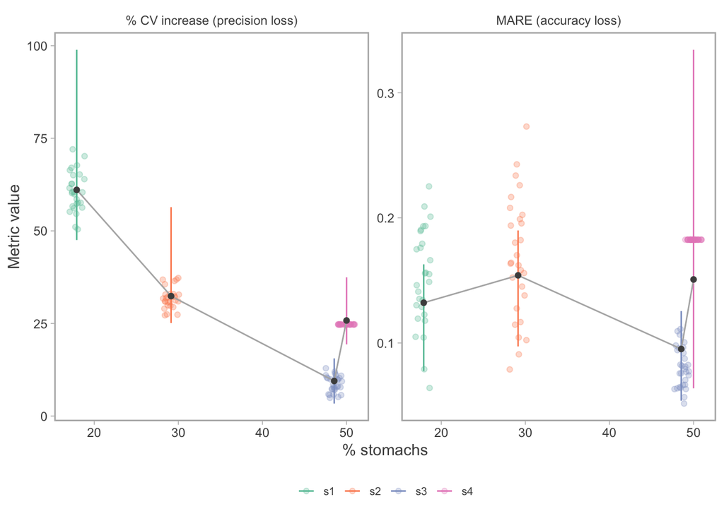

```r
ggsave(paste0(home, "/figures/metrics_comp.png"),
       width = 20, height = 8.5, units = "cm")

# Plot CV and MARE against sample size
# Calculate both CV and MARE for each iteration in one pipe
ind_comp_sp_iter_combined <- ind |>
  summarise(est = mean(est),
            lwr = mean(lwr),
            upr = mean(upr),
            log_est = mean(log_est),
            se = mean(se, na.rm = TRUE),
            .by = c(year, prey_group, scenario, iteration)) |>
  filter(!scenario == "all") |>
  left_join(all_scen, by = c("year", "prey_group")) |>
  mutate(
    precision = sqrt(exp((se^2)) - 1),
    precision_ref = sqrt(exp((se_ref^2)) - 1),
    CV = ((precision - precision_ref) / precision_ref) * 100,
    RE = (est - est_ref) / est_ref,
    abs_RE = abs(RE)
  ) |>
  # Median across years for each prey group
  summarise(
    CV = median(CV),
    MARE = median(abs_RE),
    .by = c(prey_group, scenario, iteration)
  ) |>
  # Median across prey groups for each iteration
  summarise(
    CV = median(CV),
    MARE = median(MARE),
    .by = c(scenario, iteration)
  ) |>
  pivot_longer(c(CV, MARE), names_to = "metric", values_to = "median") |>
  rename(Scenario = scenario) |>
  left_join(dsum |>
              summarise(Percent = mean(Percent), .by = Scenario),
            by = c("Scenario")) |>
  mutate(Percent = ifelse(Scenario == "s4", Percent/2, Percent))

# Summary for error bars (mean across prey groups)
metric_sample <- metrics |>
  filter(name %in% c("CV", "MARE")) |>
  summarise(median = mean(median),
            lwr = mean(lwr),
            upr = mean(upr),
            .by = c(scenario, name)) |>
  rename(Scenario = scenario, metric = name) |>
  left_join(dsum |>
              summarise(Percent = mean(Percent), .by = Scenario),
            by = "Scenario") |>
  mutate(Percent = ifelse(Scenario == "s4", Percent/2, Percent))

# Create faceted plot
ggplot(metric_sample, aes(Percent, median, label = Scenario, color = Scenario)) +
  facet_wrap(~metric, scales = "free_y",
             labeller = labeller(metric = c(
               "CV" = "% CV increase (precision loss)",
               "MARE" = "MARE (accuracy loss)"
             ))) +
  geom_jitter(data = ind_comp_sp_iter_combined, height = 0, width = 1,
              alpha = 0.3) +
  geom_errorbar(aes(ymin = lwr, ymax = upr), width = 0) +
  geom_path(color = "grey70") +
  geom_point(size = 1.5, color = "grey30") +
  #geom_label() +
  labs(y = "Metric value",
       x = "% stomachs") +
  theme(legend.position = "bottom",
        legend.title = element_blank()) +
  scale_color_brewer(palette = "Set2") #+
```

```r
  #guides(color = "none")

ggsave(paste0(home, "/figures/cv_mare_n.png"), width = 18, height = 11, units = "cm")
```

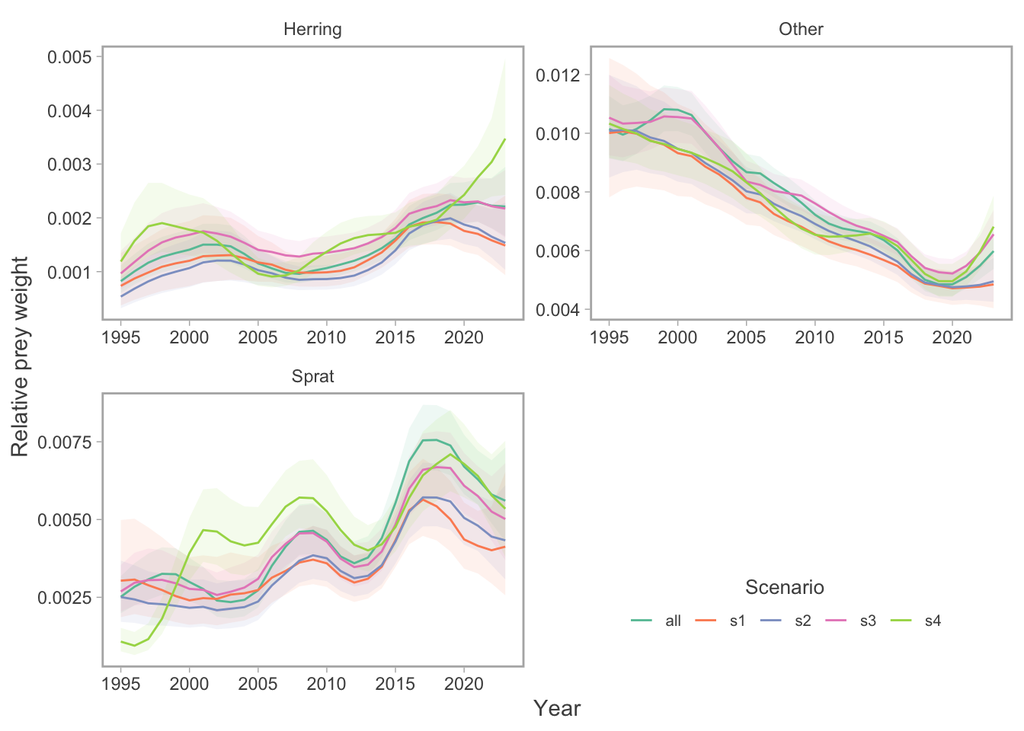

```r
# Comparing scenarios by prey group
ggplot(ind_sum, aes(year, est, fill = scenario, color = scenario)) +
  geom_ribbon(aes(ymin = lwr, ymax = upr),
    alpha = 0.1, color = NA
  ) +
  geom_line() +
  scale_color_brewer(palette = "Set2") +
  scale_fill_brewer(palette = "Set2") +
  guides(
    fill = "none",
    color = guide_legend(
      position = "inside",
      title.position = "top",
      title.hjust = 0.5
    )
  ) +
  labs(
    y = "Relative prey weight",
    x = "Year",
    color = "Scenario"
  ) +
  facet_wrap(~prey_group, scales = "free", ncol = 2) +
  theme(
    legend.position.inside = c(0.75, 0.1),
    legend.direction = "horizontal"
  ) +
  NULL
```

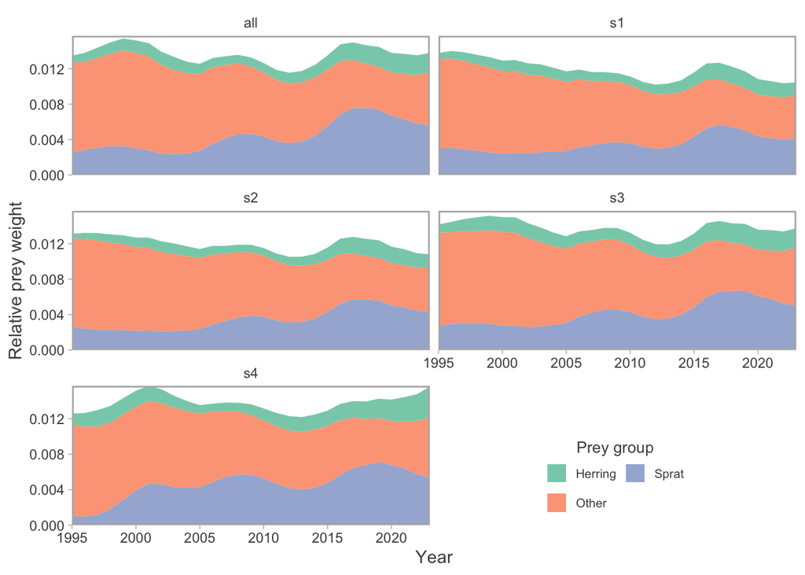

```r
ggsave(paste0(home, "/figures/scenario_comp.png"), width = 17, height = 17, units = "cm")

# Prey composition by scenario
ggplot(ind_sum, aes(year, est, fill = prey_group)) +
  geom_area(stat = "identity", alpha = 0.8) +
  facet_wrap(~scenario, ncol = 2) +
  scale_fill_brewer(palette = "Set2") +
  labs(
    y = "Relative prey weight",
    x = "Year",
    fill = "Prey group"
  ) +
  guides(fill = guide_legend(
    position = "inside",
    ncol = 2,
    title.position = "top",
    title.hjust = 0.5
  )) +
  coord_cartesian(expand = 0) +
  theme(
    legend.position.inside = c(0.75, 0.1),
    legend.direction = "horizontal"
  ) +
  NULL
```

```r
ggsave(paste0(home, "/figures/prey_comp.png"), width = 17, height = 17, units = "cm")


# Loop through each scenario + species
for (i in unique(ind$prey_group)) {

  sub <- ind_sum |>
    rename(data = y_mean) |>
    pivot_longer(c("est", "data")) |>
    filter(prey_group == i)

  sub_ind <- ind |>
    filter(prey_group == i) |>
    filter(!scenario == "all")

  ggplot() +
    facet_wrap(~scenario, ncol = 2) +
    geom_ribbon(
      data = sub |> filter(name == "est"),
      aes(year, value, ymin = lwr, ymax = upr),
      alpha = 0.2, color = NA
    ) +
    geom_line(
      data = sub_ind, inherit.aes = FALSE, color = "grey30",
      aes(year, est, group = iteration), alpha = 0.18, linewidth = 0.3,
    ) +
    geom_line(
      data = sub |> filter(name == "est"),
      linetype = 2,
      aes(year, value, color = name)
    ) +
    geom_point(
      data = sub |> filter(name == "data"),
      aes(year, value, color = name), alpha = 0.5
    ) +
    guides(color = guide_legend(
      position = "inside",
      ncol = 2
    )) +
    coord_cartesian(expand = 0) +
    theme_sleek(base_size = 13)+
    theme(
      legend.title = element_blank(),
      legend.position.inside = c(0.75, 0.1),
      legend.direction = "horizontal"
      ) +
    scale_color_brewer(palette = "Set2") +
    scale_fill_brewer(palette = "Set2") +
    labs(
      y = "Relative prey weight",
      x = "Year"
    )

  ggsave(paste0(home, "/figures/supp/index_vs_data_", i, ".png"), width = 17, height = 17, units = "cm")
}
```

```
rename: renamed one variable (data)
```

```
pivot_longer: reorganized (est, data) into (name, value) [was 435x9, now 870x9]
```

```
filter: removed 580 rows (67%), 290 rows remaining
```

```
filter: removed 8,700 rows (67%), 4,350 rows remaining
```

```
filter: removed 928 rows (21%), 3,422 rows remaining
```

```
filter: removed 145 rows (50%), 145 rows remaining
filter: removed 145 rows (50%), 145 rows remaining
filter: removed 145 rows (50%), 145 rows remaining
```

```
rename: renamed one variable (data)
```

```
pivot_longer: reorganized (est, data) into (name, value) [was 435x9, now 870x9]
```

```
filter: removed 580 rows (67%), 290 rows remaining
```

```
filter: removed 8,700 rows (67%), 4,350 rows remaining
```

```
filter: removed 928 rows (21%), 3,422 rows remaining
```

```
filter: removed 145 rows (50%), 145 rows remaining
filter: removed 145 rows (50%), 145 rows remaining
filter: removed 145 rows (50%), 145 rows remaining
```

```
rename: renamed one variable (data)
```

```
pivot_longer: reorganized (est, data) into (name, value) [was 435x9, now 870x9]
```

```
filter: removed 580 rows (67%), 290 rows remaining
```

```
filter: removed 8,700 rows (67%), 4,350 rows remaining
```

```
filter: removed 928 rows (21%), 3,422 rows remaining
```

```
filter: removed 145 rows (50%), 145 rows remaining
filter: removed 145 rows (50%), 145 rows remaining
filter: removed 145 rows (50%), 145 rows remaining
```

```r
# s6 |>
#   summarise(n = length(unique(pred_id)),
#             .by = c(year, quarter, ices_rect, length_group, Country)) |>
#   arrange(desc(n))
```

## For a given year, prey group and predator length, how many samples until asymptotic estimate? (non-spatial approach)

```r
# # Generate random data
# # https://stackoverflow.com/questions/69141793/simulate-in-r-the-number-of-samples-needed-in-order-to-achieve-the-true-standard
#
# # Define the sample sizes
# sample_size <- 1:1300
#
# # Function to calculate sigma_m
# calc_mean <- function(n, x) {
#   mean(sample(x, n, replace = TRUE))
# }
#
# d <- d |>
#   mutate(
#     life_stage = ifelse(pred_length > 25, "Adult", "Juvenile"),
#     id = paste(prey_group, life_stage, sep = ":")
#   )
#
# cumulative_means <- list()
#
# for (i in unique(d$id)) {
#   x <- d |> filter(id == i)
#
#   dft <- tibble(sample_size) |>
#     mutate(mean = map_dbl(sample_size, ~ calc_mean(.x, x$rpw)))
#
#   cumulative_means[[i]] <- dft |> mutate(id = i)
# }
#
# cm <- bind_rows(cumulative_means) |>
#   separate(id, into = c("prey_group", "life_stage"), sep = ":")
#
# ggplot(cm, aes(sample_size, mean, color = life_stage)) +
#   facet_wrap(~prey_group, scales = "free_y", ncol = 2) +
#   geom_line(alpha = 0.8) +
#   labs(x = "Sample size", y = "Mean", color = "Prey group") +
#   scale_color_brewer(palette = "Set2") +
#   guides(color = guide_legend(
#     position = "inside",
#     ncol = 2,
#     title.position = "top",
#     title.hjust = 0.5
#   )) +
#   theme(
#     legend.position.inside = c(0.75, 0.1),
#     legend.direction = "horizontal"
#   ) +
#   coord_cartesian(xlim = c(0, 300)) +
#   NULL
#
# ggsave(paste0(home, "/figures/supp/cumulative_means.png"), width = 17, height = 17, units = "cm")
#
# cm_sum <- cm |>
#   mutate(sample_group = cut(sample_size, breaks = seq(0, 1300, by = 5))) |>
#   summarise(
#     sd = sd(mean),
#     mean = mean(mean),
#     cv = sd / mean,
#     .by = c(sample_group, life_stage, prey_group)
#   ) |>
#   separate(sample_group, into = c("lwr", "upr"), sep = ",") |>
#   mutate(upr = as.numeric(str_remove(upr, "]")))
#
# ggplot(cm_sum, aes(upr, cv, linetype = life_stage)) +
#   facet_wrap(~prey_group, scales = "free_y", ncol = 2) +
#   geom_line(alpha = 0.8) +
#   geom_smooth(method = "gam", formula = y ~ s(x, k = 3), se = FALSE, linewidth = 0.5) +
#   labs(x = "Sample size", y = "CV", color = "Scenario", linetype = "Life stage") +
#   scale_color_brewer(palette = "Set2") +
#   guides(color = guide_legend(
#     position = "inside",
#     title.position = "top",
#     title.hjust = 0.5
#   ),
#   linetype = guide_legend(
#     position = "inside",
#     title.position = "top",
#     title.hjust = 0.5
#   )) +
#   theme(
#     legend.position.inside = c(0.75, 0.1),
#     legend.direction = "horizontal"
#   ) +
#   geom_vline(data = dsum |> summarise(n = mean(mean), .by = Scenario),
#              aes(xintercept = n, color = Scenario)) +
#   NULL
#
# ggsave(paste0(home, "/figures/supp/cumulative_cv_with_data.png"), width = 17, height = 17, units = "cm")
```

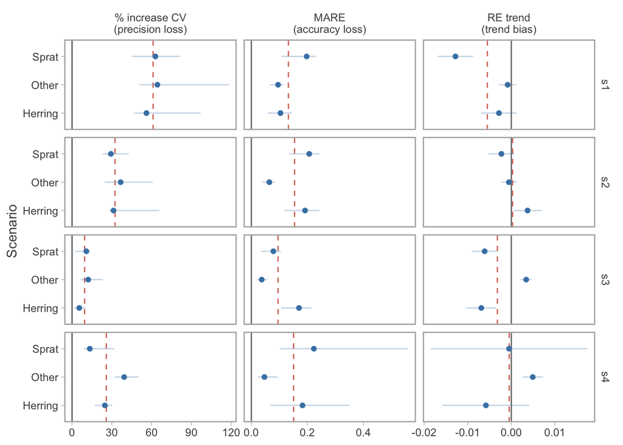

```r
ggplot(metrics, aes(median, prey_group)) +
  ggh4x::facet_grid2(scenario ~ factor(name, levels = c("CV", "MARE", "Trends")),
    scales = "free_x",
    labeller = labeller(
      `factor(name, levels = c("CV", "MARE", "Trends"))` = c(
        "CV" = "% increase CV\n(precision loss)",
        "MARE" = "MARE\n(accuracy loss)",
        "Trends" = "RE trend\n(trend bias)")
  )) +
  geom_vline(xintercept = 0, alpha = 0.8, color = "grey30") +
  geom_vline(
    data = means, aes(xintercept = mean),
    alpha = 0.8, linetype = 2, color = "tomato3"
  ) +
  geom_point(position = position_dodge(width = 0.2), color = "steelblue") +
  geom_errorbar(aes(median, prey_group, xmin = lwr, xmax = upr),
    width = 0,
    alpha = 0.3, position = position_dodge(width = 0.2),
    color = "steelblue"
  ) +
  scale_color_brewer(palette = "Set2") +
  theme(
    axis.title.x = element_blank(),
    legend.position = "bottom",
    legend.title = element_blank()
  ) +
  labs(x = "% change", y = "Scenario")
```

```r
#ggsave(paste0(home, "/figures/metrics_comp.png"), width = 20, height = 14, units = "cm")
```